# Part II - Data exploratory of Prosper Loans After July 2009

## by Akorede Ridwanullahi Abiodun

## Investigation Overview

In this investigation, I wanted to look at the details of the people that applied for Prospers loans from July 2009.

## Dataset Overview

The original data contain 113937 loans which entail 81 variables on each loan. The data was filtered down to contain only loans applied after July 2009 and some unused variables were dropped while the variables were reduced to 19.

## Distribution of Borrower Annual Percentage Rate

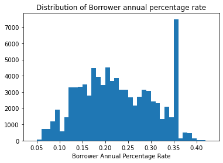

## DIstribution of Borrower Interest Rate

The prosper borrower interest rate in the dataset take on a very range of values from 0.04 which is the lowest to 0.35. Within there is a significant rise at 0.32 which has the distribution, the distribution of borrower interest rate takes on a multimodal shape.

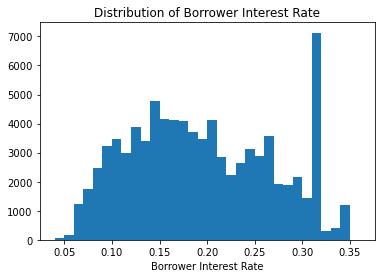

## State of the Loan Status

With the outcome of the plot, it has vividly shown that most of the loan statuses are current while final payment progress maintains the least

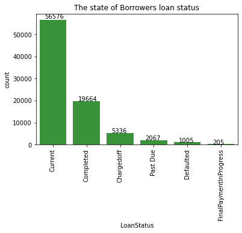

## Borrowers by State

One of the criteria of the application is to track the borrowers using their information, and it appears that the bulk of borrowers reside in California (CA), with Wyoming having the lowest number.

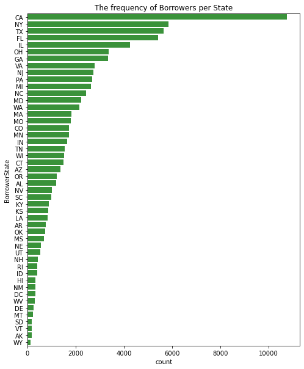

## Borrower by Listing Category

It has been demonstrated with a plot that the majority of applicants for loans cited debt consolidation as their rationale, whilst the least number of applicants cited not availabe as their reason.

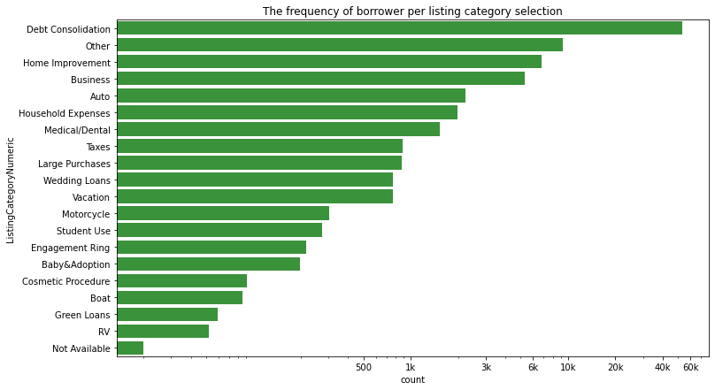

## Borrower Employment status

It has been demonstrated with a plot that the majority of applicants for loans are employed , whilst the least number of applicants cited are not employed.

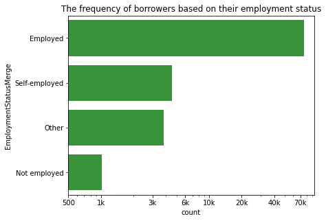